# Biostat M280 Homework 4

Due Mar 16 @ 11:59PM

Sarah Ji

Our Apache Yarn cluster hosts the [flights](http://stat-computing.org/dataexpo/2009/the-data.html) data representing 123 million flights over 22 years. Read the [lecture notes](http://hua-zhou.github.io/teaching/biostatm280-2018winter/slides/12-sparklyr/sparklyr-flights.html) on how to access the Yarn cluster. Connect to the database using `sparklyr` and answer following questions. You can base your answers on a specific year or the whole data set.

1. Map the top 10 busiest airports. Size of dots should reflect the number of flights through that destination.  
   Hint: You may find this tutorial on [Making Maps in R](http://eriqande.github.io/rep-res-web/lectures/making-maps-with-R.html) helpful.

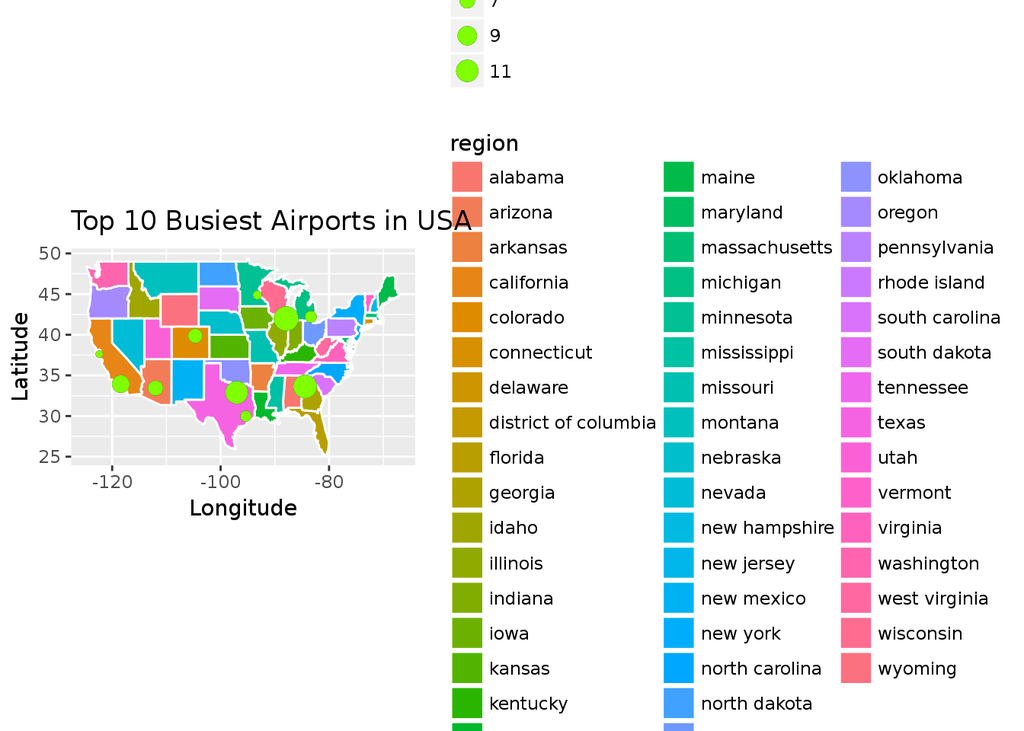

2. Map the top 10 busiest direct routes. Size of lines should reflect the number of flights through that route.

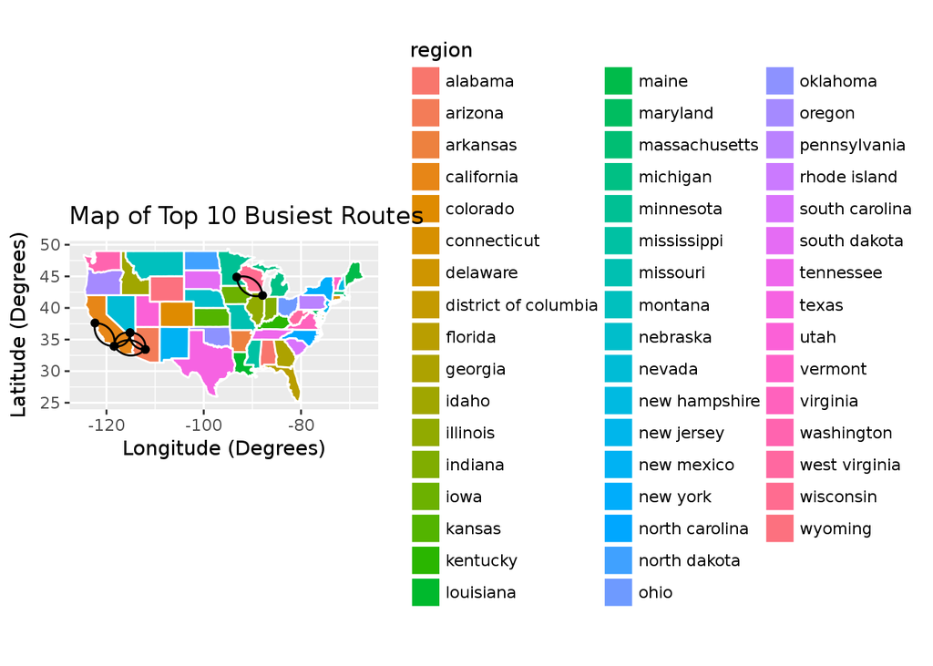

**Answer**: The top 10 busiest direct routes with the highest number of flights through that route are: 1) SFO - LAX 2) LAX - SFO 3) LAX - LAS 4) LAS - LAX 5) PHX - LAX 6) LAX - PHX 7) ORD - MSP 8) MSP - ORD 9) PHX - LAS 10) LAS - PHX

3. LAX:

   (a). Reproduce the plot. Visualize and explain some prominent features you observe. For example, what happened at points 1-5?

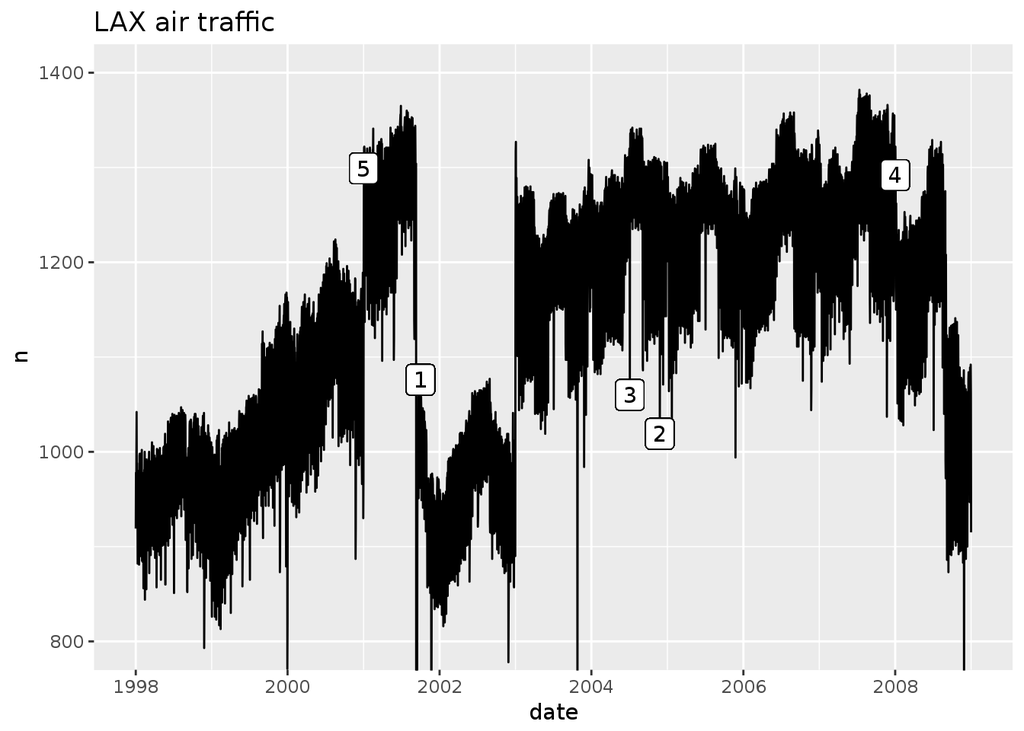

**Answer**: We have recreated the desired plot of the number of flights per day from 1998 - 2008, with points labeled 1 to 5 on the dates below: We notice there is a Holidays effect on the number of flights that come in and out of LAX per day. 9/11 is a historic moment in America, especially for those working in the airlines industry. While (1) 9/11 is not a holiday that repeats, the rest of the numbered dates are as follows:

Patterns in the data / Borderline Conspiracy Theories: (1) Fallout of 9/11. A truly tragic piece of American History unfolds and with it comes the fallout.. (2) November 25, 2004, n = 1,019 : Thanksgiving ! Everyone is flying home to see their family members to celebrate thanksgiving. or ~ The LAX Plan, a law passed on September 29, 2004, to upgrade needed facilities to accomodate current and next generation larger aircraft associated with internationa and long haul domestic travel. https://www.lawa.org/-/media/lawa-web/lawa-our-lax/finallaxplan_092904.ashx (3) July 4, 2004, n = 1,060 : Independence Day! (4) January 1, 2008, n = 1,292 : New Years Day! or ~ brings on a grim year for a financial crash soon to come, risk averse population. or ~ The super jumbo jet A380 by Airbus was intended to have its first landing in the United States at the LAX airport in September. The A380, is the largest commercial plane that seats 555 passengers, significantly more than it’s predecessor, the 747. The airbus could help space-constrained airports, including LAX, by allowing carriers to combine several flights into one. http://www.latimes.com/travel/la-trw-airbus18mar18-story.html (5) January 1, 2001, n = 1,299: New Years Day!

```
(b). Visualize and explain seasonal effects.
```

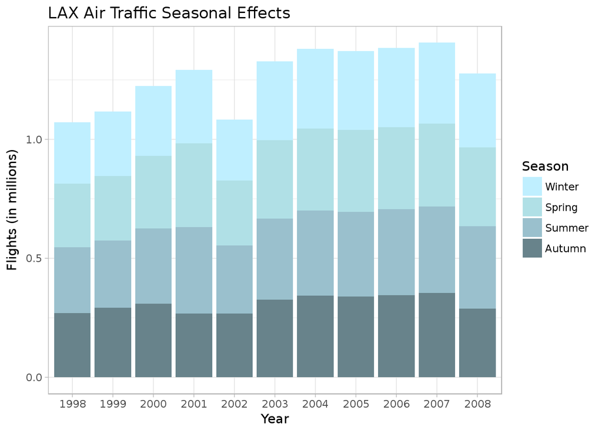

```
(c). Visualize and explain weekly effects.
```

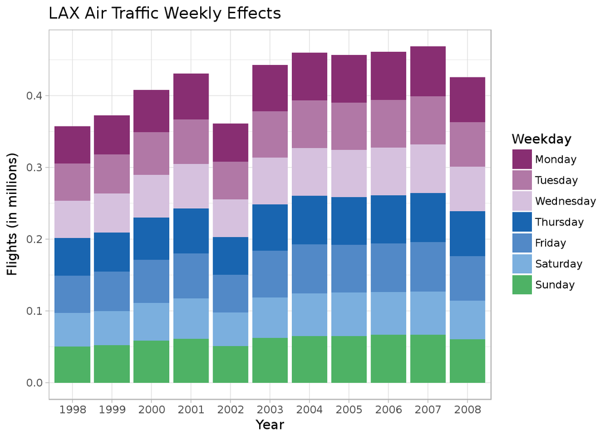

**Answer**: Above we visualize the number of flights per year (in millions), by weekday. Notice that the weekly effect stays consistent over the years.

[output not shown]

4. Build a predictive model for the arrival delay (`arrdelay`) of flights flying from LAX. Use the same filtering criteria as in the [lecture notes](http://hua-zhou.github.io/teaching/biostatm280-2018winter/slides/12-sparklyr/sparklyr-flights.html) to construct training and validation sets. You are allowed to use a maximum of 5 predictors. The prediction performance of your model on the validation data set will be an important factor for grading this question.

```
## Call: ml_linear_regression.tbl_spark(., arrdelay ~ distance + depdelay + uniquecarrier + tz_name + alt)
##
## Deviance Residuals (approximate):
##      Min       1Q   Median       3Q      Max
## -192.495   -6.969   -1.372    5.269  328.814
##
## Coefficients:
##                 (Intercept)                    distance
##                -43.25170616                  0.01003732
##                    depdelay            uniquecarrier_WN
##                  1.01101673                 -1.66672201
##            uniquecarrier_OO            uniquecarrier_AA
##                  0.50387188                  1.75039967
##            uniquecarrier_UA            uniquecarrier_DL
##                 -0.82731572                  2.37851513
##            uniquecarrier_AS            uniquecarrier_MQ
##                 -1.25395210                 -0.47553557
##            uniquecarrier_CO            uniquecarrier_NW
##                  3.93569110                  4.42646386
##            uniquecarrier_US            uniquecarrier_HP
##                  1.65885907                 -0.88893128
##            uniquecarrier_XE            uniquecarrier_F9
##                  1.16702595                  0.97015010
##            uniquecarrier_TZ            uniquecarrier_FL
##                  7.01807649                  2.78142503
##            uniquecarrier_EV            uniquecarrier_YV
##                  0.70271097                 -0.63173129
##            uniquecarrier_HA            uniquecarrier_DH
##                 -0.42014765                 13.88968273
## tz_name_America/Los_Angeles    tz_name_America/New_York
##                 39.03129651                 13.09512841
##     tz_name_America/Chicago      tz_name_America/Denver
##                 18.48786455                 16.60277654
##     tz_name_America/Phoenix    tz_name_Pacific/Honolulu
##                 18.83297331                  7.92218370
##   tz_name_America/Anchorage                      alt_13
##                  6.96249849                  2.61103155
##                    alt_2181                    alt_1135
##                  2.79372013                 17.99954349
##                       alt_9                     alt_672
```

[output cut: 65 more lines]

```
##                     alt_173                     alt_435
##                 -0.18987877                 -1.10914879
##                    alt_7820                      alt_30
##                 11.58851889                 -1.26743540
##                    alt_1333                      alt_11
##                 10.08040497                  2.83287716
##                     alt_374                    alt_5759
##                -12.72750750                  4.10427898
##                     alt_107                      alt_21
##                 10.59650132                -22.61031176
##                     alt_295                    alt_6451
##                  7.72733418                  0.00000000
##
## R-Squared: 0.8861
## Root Mean Squared Error: 13.26
```

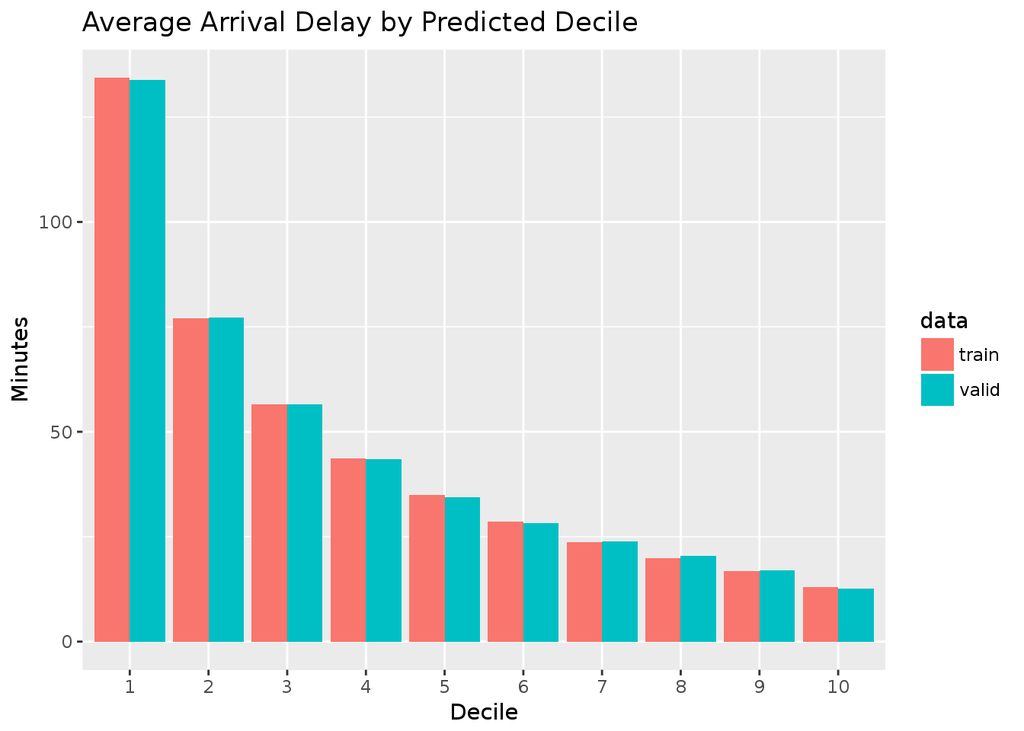

[output not shown]

[output cut: 41 more lines]

[output not shown]

5. Visualize and explain any other information you want to explore.

[output not shown]

[output not shown]

[output not shown]